# Regression Analysis

### Predicting happiness levels using single and multiple regression modelling.

- Writen by Leonard Phillips

## Data Acquisition

In this report, I will attempt to predict happiness using based on independent variables from The World Bank. Throughout this report, I have explained each step and evaluated my findings.

I have retrieved this data set from the World Bank. It includes many indicators that might have contributing factors to the happiness level of a country.

```python
import seaborn as sns
import pandas as pd
import numpy as np
import requests
import json
from bs4 import BeautifulSoup
import matplotlib.pyplot as plt


%matplotlib inline
```

```python
WHRData = pd.read_excel("WHRData.xls", sheet_name="Table2.1")
WHRData.head(5)
```

|  | Country name | Year | Life Ladder | Log GDP per capita | Social support | Healthy life expectancy at birth | Freedom to make life choices | Generosity | Perceptions of corruption | Positive affect | ... | GINI index (World Bank estimate) | GINI index (World Bank estimate), average 2000-16 | gini of household income reported in Gallup, by wp5-year | Most people can be trusted, Gallup | Most people can be trusted, WVS round 1981-1984 | Most people can be trusted, WVS round 1989-1993 | Most people can be trusted, WVS round 1994-1998 | Most people can be trusted, WVS round 1999-2004 | Most people can be trusted, WVS round 2005-2009 | Most people can be trusted, WVS round 2010-2014 |
| --- | --- | --- | --- | --- | --- | --- | --- | --- | --- | --- | --- | --- | --- | --- | --- | --- | --- | --- | --- | --- | --- |
| 0 | Afghanistan | 2008 | 3.723590 | 7.168690 | 0.450662 | 50.799999 | 0.718114 | 0.177889 | 0.881686 | 0.517637 | ... | NaN | NaN | NaN | NaN | NaN | NaN | NaN | NaN | NaN | NaN |
| 1 | Afghanistan | 2009 | 4.401778 | 7.333790 | 0.552308 | 51.200001 | 0.678896 | 0.200178 | 0.850035 | 0.583926 | ... | NaN | NaN | 0.441906 | 0.286315 | NaN | NaN | NaN | NaN | NaN | NaN |
| 2 | Afghanistan | 2010 | 4.758381 | 7.386629 | 0.539075 | 51.599998 | 0.600127 | 0.134353 | 0.706766 | 0.618265 | ... | NaN | NaN | 0.327318 | 0.275833 | NaN | NaN | NaN | NaN | NaN | NaN |
| 3 | Afghanistan | 2011 | 3.831719 | 7.415019 | 0.521104 | 51.919998 | 0.495901 | 0.172137 | 0.731109 | 0.611387 | ... | NaN | NaN | 0.336764 | NaN | NaN | NaN | NaN | NaN | NaN | NaN |
| 4 | Afghanistan | 2012 | 3.782938 | 7.517126 | 0.520637 | 52.240002 | 0.530935 | 0.244273 | 0.775620 | 0.710385 | ... | NaN | NaN | 0.344540 | NaN | NaN | NaN | NaN | NaN | NaN | NaN |

5 rows × 26 columns

### Dynamic Data

To practice my data acquisition abilities and increase the number of independent variables, I have collected 5 indicators from The World Bank's API and have included them in my data set.

These indicators are:

1. CO2 emissions (metric tons per capita)
2. Government expenditure on education, total (% of GDP)
3. Employment to population ratio, 15+, total (%) (modeled ILO estimate)
4. School enrollment, tertiary (% gross)
5. Total Population

The variables I want to be included in my regression model should be coming from different areas unrelated to each other. I wanted diverse variables coming from sectors such as education, labour, environmental and population size.

To retire these indicators, it was important to search through the World Bank world development indicators webpage. This page contained hundreds of indicators.

Once I found the indicators that supported the 'WHRData' I proceeded to read through the API documentation. The following code uses the World Bank API to request 5 indicators that are appropriate to our current 'WHRData' dataset.

```python
WHRData = pd.read_excel("WHRData.xls", sheet_name="Table2.1")


frames = []
worldbank_df = []
first_recorded_year = WHRData['Year'].unique()[-1]   # Get the lowest recorded year in WHRData. Earlest recorded year was 2005.
indicators = ['EN.ATM.CO2E.PC','SE.XPD.TOTL.GD.ZS','SL.EMP.TOTL.SP.ZS','SE.TER.ENRR','SP.POP.TOTL']
for indicator in indicators:
    url = "http://api.worldbank.org/v2/country/all/indicators/%s?date=%s:2018&format=json" % (indicator,first_recorded_year)
    response = requests.get(url)
    result = json.loads(response.content)

    total = result[0]['total']
    url = "http://api.worldbank.org/v2/country/all/indicators/%s?date=%s:2018&format=json&per_page=%s" % (indicator,first_recorded_year,total)
    response = requests.get(url)
    result = json.loads(response.content)

    worldbank_df = pd.DataFrame.from_dict(result[1])
    worldbank_df = worldbank_df[worldbank_df['countryiso3code'] != ""]   # Removes regional data preceding country data
    worldbank_df['country'] = worldbank_df[['country']].applymap(lambda x : x['value'])   # Extracts values from dict in each row

    worldbank_df = worldbank_df[["country", "date", "value"]]   # Extracts only the data we are interested in
    worldbank_df.columns = ["Country name", "Year", result[1][0]['indicator']['value']]   # Renames value column to give meaning
    frames.append(worldbank_df)
```

For easy working we will merge our frames together:

```python
worldbank_df = pd.DataFrame(frames[0][["Country name", "Year"]])
for frame in frames:
    worldbank_df = pd.merge(worldbank_df, frame, how="inner", on=["Country name", "Year"])
worldbank_df.head(5)
```

|  | Country name | Year | CO2 emissions (metric tons per capita) | Government expenditure on education, total (% of GDP) | Employment to population ratio, 15+, total (%) (modeled ILO estimate) | School enrollment, tertiary (% gross) | Population, total |
| --- | --- | --- | --- | --- | --- | --- | --- |
| 0 | Afghanistan | 2018 | NaN | NaN | 64.939003 | 9.99214 | NaN |
| 1 | Afghanistan | 2017 | NaN | 3.92675 | 64.858002 | NaN | 36296400.0 |
| 2 | Afghanistan | 2016 | NaN | 4.20525 | 64.511002 | NaN | 35383128.0 |
| 3 | Afghanistan | 2015 | NaN | 3.24202 | 64.172997 | NaN | 34413603.0 |
| 4 | Afghanistan | 2014 | 0.293946 | 3.67390 | 63.665001 | 8.47570 | 33370794.0 |

### Integration

The code below finds country names that are missing in both the WHRData set and our 5 indicator dataset, combines them together and sorts them by alphabetical order. The idea here is that names that are misspelled will likely still have the same first letter in the name. If they don't then it is just a matter of searching through the entire 94 elements and looking for names that are similar.

```python
list_of_nonmatching_names = []
not_in_indicator = []
not_in_WHR = []

#  Checking WHR names not in indicator
for names in WHRData['Country name'].unique():
    if names not in worldbank_df['Country name'].unique():
        not_in_indicator.append(names)


# Checking indicator names not in WHR
for names in worldbank_df['Country name'].unique():
    if names not in WHRData['Country name'].unique():
        not_in_WHR.append(names)

print(sorted(not_in_indicator + not_in_WHR), '\n')
```

```
['American Samoa', 'Andorra', 'Antigua and Barbuda', 'Aruba', 'Bahamas, The', 'Barbados', 'Bermuda', 'British Virgin Islands', 'Brunei Darussalam', 'Cabo Verde', 'Cayman Islands', 'Channel Islands', 'Congo (Brazzaville)', 'Congo (Kinshasa)', 'Congo, Dem. Rep.', 'Congo, Rep.', "Cote d'Ivoire", 'Curac…
```

From the above list of names I managed to find 15 incorrect names:

Now that we have the list of incorrect names, we need to correct them in the WHRData dataset

```python
name_pairs = {'Congo, Rep.':'Congo (Brazzaville)',
              'Congo, Dem. Rep.':'Congo (Kinshasa)',
              'Egypt, Arab Rep.':'Egypt',
              'Gambia, The':'Gambia',
             'Hong Kong SAR, China':'Hong Kong S.A.R. of China',
              'Iran, Islamic Rep.':'Iran',
              'Korea, Rep.':'South Korea',
             'Kyrgyz Republic':'Kyrgyzstan',
              'Lao PDR':'Laos',
              'Russian Federation':'Russia',
              'Slovak Republic':'Slovakia',
              'Syrian Arab Republic':'Syria',
              'Venezuela, RB':'Venezuela',
              'West Bank and Gaza':'Palestinian Territories',
             'Yemen, Rep.':'Yemen'}

worldbank_df['Country name'] = worldbank_df['Country name'].replace(name_pairs)
```

This will prevent any new rows being added to the left DF while merging the two together. It is important to keep the WHRData DF untouched as it is our base DF. We want to prevent changing a previously cleaned DF.

We can test this by taking a 'Country name' row value that exists in CO2 emissions indicator but does not exist in WHRData. One such value is 'American Samoa'.

First find a value that exists in CO2 emissions indicator:

```python
# Tests whether American Samoa is in CO2 emissions indicator
'American Samoa' in worldbank_df['Country name'].unique()
```

```
True
```

Before preforming the merge the column data must be of consistent type to merge:

```python
worldbank_df['Year'] = pd.to_numeric(worldbank_df['Year'])   # Merge can not happen unless columns are of the same type
```

Then perform the merge (intergration) between WHRData and each indicator:

```python
WHRData = pd.merge(WHRData, worldbank_df, how="inner", on=["Country name", "Year"])
```

Then test to see whether that value has been included in the nemly merged DF. This line should produce a false result:

```python
# Tests whether American Samoa is in WHRData
'American Samoa' in WHRData['Country name'].unique()
```

```
False
```

**Note** - As stated in the assignment breif, there is the chance of a country having two different names in the dataset. A visual examination of both the WHRData and worldbank_df DF yielded no obvious differences.

## Data Cleaning and Exploratory Data Analysis

### EDA - data quality inspection

After reading the Statistical Appendix 1 for Chapter 2 of World Happiness Report 2019, I have ecided to make some changes to the column names and data with the objective of better understanding the data. Below are a list of changes I have made:

```python
WHRData = WHRData.rename(columns = {'Life Ladder':'Life Ladder (between 0 and 10)','Social Support':'Social Support (between 0 and 1)'
                                    ,'Generosity':'Generosity (measuring residuals)'})
```

#### Summary Statistic

```python
WHRData['Life Ladder (between 0 and 10)'].describe()
```

```
count    1663.000000
mean        5.441121
std         1.127857
min         2.661718
25%         4.608994
50%         5.343166
75%         6.277411
max         8.018934
Name: Life Ladder (between 0 and 10), dtype: float64
```

Examining the summary statistic above we notice that the standard deviation from the mean is 1.12. This indicates that our data has a low amount of spread. A visual examination might find a normally distributed shape. The 25% and 75% percentile is not a very low and high number respectively. This shows us that there are no local peaks in the tails of the data.

#### Histogram

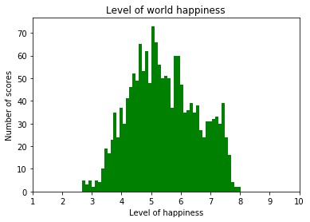

```python
bins = [1,2,3,4,5,6,7,8,9,10]
plt.hist(WHRData['Life Ladder (between 0 and 10)'],bins=50,facecolor='green',linewidth=1)
plt.title("Level of world happiness")
plt.xticks(bins)
plt.ylabel("Number of scores")
plt.xlabel("Level of happiness")
plt.show()
```

A visual examination of the histogram above reveals a unimodal distribution of the data. The peak is around the center of the data which is what we expect to see. There are no visible outliers.

#### NaN values

```python
WHRData['Life Ladder (between 0 and 10)'].isna().any()
```

```
False
```

The code above tells us whether NaN values exists in the data. A false response means there are no NaN values present. We can now be assured that there will be no bias caused by NaN values present in our data.

#### Duplicates

```python
WHRData[['Country name', 'Year']].duplicated().any()
```

```
False
```

#### Results

After examination of the data, I conclude the data is appropriate for analysis.

Finally, I have saved this cleaned dataset into a csv file called 'cleanedWHRData.csv'.

```python
WHRData.to_csv('cleanedWHRData.csv')
```

### b) EDA - the search for good predictors

#### Correlation Matric

The following script calculates the correlation between all variables, keeping only pairs with a correlation above 75%.

```python
corr_df = WHRData.corr()
corr_df = corr_df.where((corr_df != 1) & (corr_df > 0.75) | (corr_df < -0.75))
for header in corr_df.columns:
    if corr_df[header].isna().all():
        corr_df.drop(header, axis=1, inplace=True)
        corr_df.drop(header, axis=0, inplace=True)

corr_df
```

|  | Life Ladder (between 0 and 10) | Log GDP per capita | Healthy life expectancy at birth | Perceptions of corruption | Democratic Quality | Delivery Quality | Standard deviation of ladder by country-year | Standard deviation/Mean of ladder by country-year | GINI index (World Bank estimate) | GINI index (World Bank estimate), average 2000-16 | Most people can be trusted, Gallup | Most people can be trusted, WVS round 1981-1984 | Most people can be trusted, WVS round 1989-1993 | Most people can be trusted, WVS round 1994-1998 | Most people can be trusted, WVS round 1999-2004 | Most people can be trusted, WVS round 2005-2009 | Most people can be trusted, WVS round 2010-2014 | School enrollment, tertiary (% gross) |
| --- | --- | --- | --- | --- | --- | --- | --- | --- | --- | --- | --- | --- | --- | --- | --- | --- | --- | --- |
| Life Ladder (between 0 and 10) | NaN | 0.779805 | NaN | NaN | NaN | NaN | NaN | -0.753858 | NaN | NaN | NaN | NaN | NaN | NaN | NaN | NaN | NaN | NaN |
| Log GDP per capita | 0.779805 | NaN | 0.834937 | NaN | NaN | 0.768787 | NaN | NaN | NaN | NaN | NaN | 0.841856 | NaN | NaN | NaN | NaN | NaN | 0.775180 |
| Healthy life expectancy at birth | NaN | 0.834937 | NaN | NaN | NaN | NaN | NaN | NaN | NaN | NaN | NaN | NaN | NaN | NaN | NaN | NaN | NaN | 0.756006 |
| Perceptions of corruption | NaN | NaN | NaN | NaN | NaN | NaN | NaN | NaN | NaN | NaN | NaN | -0.790999 | NaN | NaN | NaN | NaN | NaN | NaN |
| Democratic Quality | NaN | NaN | NaN | NaN | NaN | 0.858993 | NaN | NaN | NaN | NaN | NaN | 0.948117 | NaN | NaN | NaN | NaN | NaN | NaN |
| Delivery Quality | NaN | 0.768787 | NaN | NaN | 0.858993 | NaN | NaN | NaN | NaN | NaN | NaN | 0.939116 | NaN | NaN | NaN | NaN | NaN | NaN |
| Standard deviation of ladder by country-year | NaN | NaN | NaN | NaN | NaN | NaN | NaN | NaN | NaN | NaN | NaN | -0.758706 | NaN | NaN | NaN | NaN | NaN | NaN |
| Standard deviation/Mean of ladder by country-year | -0.753858 | NaN | NaN | NaN | NaN | NaN | NaN | NaN | NaN | NaN | NaN | NaN | NaN | NaN | NaN | NaN | NaN | NaN |
| GINI index (World Bank estimate) | NaN | NaN | NaN | NaN | NaN | NaN | NaN | NaN | NaN | 0.974755 | NaN | NaN | NaN | NaN | NaN | NaN | NaN | NaN |
| GINI index (World Bank estimate), average 2000-16 | NaN | NaN | NaN | NaN | NaN | NaN | NaN | NaN | 0.974755 | NaN | NaN | NaN | NaN | NaN | NaN | NaN | NaN | NaN |
| Most people can be trusted, Gallup | NaN | NaN | NaN | NaN | NaN | NaN | NaN | NaN | NaN | NaN | NaN | 0.834360 | 0.821924 | 0.796080 | NaN | NaN | 0.822666 | NaN |
| Most people can be trusted, WVS round 1981-1984 | NaN | 0.841856 | NaN | -0.790999 | 0.948117 | 0.939116 | -0.758706 | NaN | NaN | NaN | 0.834360 | NaN | NaN | 0.842957 | 0.881015 | 0.956255 | 0.953022 | NaN |
| Most people can be trusted, WVS round 1989-1993 | NaN | NaN | NaN | NaN | NaN | NaN | NaN | NaN | NaN | NaN | 0.821924 | NaN | NaN | 0.832374 | 0.811915 | 0.770085 | 0.875506 | NaN |
| Most people can be trusted, WVS round 1994-1998 | NaN | NaN | NaN | NaN | NaN | NaN | NaN | NaN | NaN | NaN | 0.796080 | 0.842957 | 0.832374 | NaN | 0.898331 | 0.933786 | 0.869495 | NaN |
| Most people can be trusted, WVS round 1999-2004 | NaN | NaN | NaN | NaN | NaN | NaN | NaN | NaN | NaN | NaN | NaN | 0.881015 | 0.811915 | 0.898331 | NaN | NaN | 0.768508 | NaN |
| Most people can be trusted, WVS round 2005-2009 | NaN | NaN | NaN | NaN | NaN | NaN | NaN | NaN | NaN | NaN | NaN | 0.956255 | 0.770085 | 0.933786 | NaN | NaN | 0.885755 | NaN |
| Most people can be trusted, WVS round 2010-2014 | NaN | NaN | NaN | NaN | NaN | NaN | NaN | NaN | NaN | NaN | 0.822666 | 0.953022 | 0.875506 | 0.869495 | 0.768508 | 0.885755 | NaN | NaN |
| School enrollment, tertiary (% gross) | NaN | 0.775180 | 0.756006 | NaN | NaN | NaN | NaN | NaN | NaN | NaN | NaN | NaN | NaN | NaN | NaN | NaN | NaN | NaN |

The following script creates a pair graph containing the correlation between different variables in our WHRData dataframe. Each line creates a pair graphs with different indicator variables. All pair graphs contain our target variable 'Life Ladder'.

I have done this beacuse plotting every variable produces a graph that is small and unreadable. Uncomment each line to view each correlation matric plot.

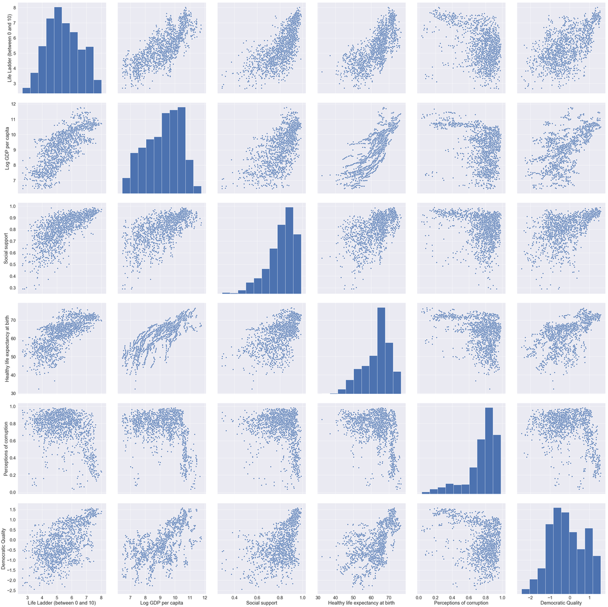

```python
headers_one = ['Life Ladder (between 0 and 10)', 'Log GDP per capita',
       'Social support', 'Healthy life expectancy at birth',
       'Perceptions of corruption', 'Democratic Quality']
headers_two = ['Life Ladder (between 0 and 10)','Delivery Quality',
       'Standard deviation of ladder by country-year',
       'Standard deviation/Mean of ladder by country-year',
       'GINI index (World Bank estimate)',
       'GINI index (World Bank estimate), average 2000-16']
headers_three = ['Life Ladder (between 0 and 10)','Most people can be trusted, Gallup',
       'Most people can be trusted, WVS round 1981-1984',
       'Most people can be trusted, WVS round 1989-1993',
       'Most people can be trusted, WVS round 1994-1998',
       'Most people can be trusted, WVS round 1999-2004']
headers_four = ['Life Ladder (between 0 and 10)', 'Most people can be trusted, WVS round 2005-2009',
       'Most people can be trusted, WVS round 2010-2014',
       'CO2 emissions (metric tons per capita)',
       'School enrollment, tertiary (% gross)']


sns.set(font_scale=2)
sns.pairplot(WHRData[headers_one],height=7)
# sns.pairplot(WHRData[headers_two],height=7)
# sns.pairplot(WHRData[headers_three],height=7)
# sns.pairplot(WHRData[headers_four],height=7)
```

After visually examining the correlation matric, we can see that there are only two predictors that have a correlation with the target variable 'Life Ladder (between 0 and 10)' above 75%. These two predictor values are 'Log GDP per capita' and 'Standard deviation/Mean of ladder by country-year'.

There is also an 83% correlation between 'Log GDP per capita' and 'Healthy life expectancy at birth'.

We can also see from the correlation matric, 'Most people can be trusted, WVS round 1981-1984' has a strong correlation with both 'Delivery Quality' (93%) and 'Democratic Quality' (94%).

#### Discussion

The six predictor variables I have selected for model prediction are:

## Modeling

It is common knowledge in New Zealand and to most of the world that we are living in one of the best places on earth and have some of the happiest citizens. A 2018, an [article](https://www.forbes.com/sites/duncanmadden/2018/03/27/ranked-the-10-happiest-countries-in-the-world-in-2018/#3be1e2f273e9) published by Forbes ranked New Zealand as the 8th happiest place in the world. It is no wonder then why so many people visit New Zealand every year.

The purpose of this report is to better understand how particular features affect happiness. This report is in two parts. The first being a look into what features effect happiness levels at a global level and the second being a look into what features affect the happiness levels of New Zealanders. For each part, I have looked at how each individual predictor variable affects the target using single variable polynomial regression modeling. I have also looked at how a combination of prediction variables has affected the target variable using step-wise multiple regression modeling.

From these two parts, I hope to better understand whether the same features that make the world happier, also make New Zealanders happier.

The following script sets the index to a composite key grouping 'Year' by 'Country name', changes the predictor variable names to acronyms for use in the ols regression model and creates a target/predictor dataframe consisting of the predictors selected in Task 2.

```python
WHRData.set_index(["Country name","Year"],inplace=True)

header_names = {'Life Ladder (between 0 and 10)':'LL', 'Log GDP per capita':'GDP',
       'Social support':'SS', 'Healthy life expectancy at birth':'HLE',
       'Freedom to make life choices':'FLC', 'Generosity (measuring residuals)':'GEN',
       'Perceptions of corruption':'POC', 'Positive affect':'PAF', 'Negative affect':'NAF',
       'Confidence in national government':'CNG', 'Democratic Quality':'DEQ',
       'Delivery Quality':'DLQ', 'Standard deviation of ladder by country-year':'SDL',
       'Standard deviation/Mean of ladder by country-year':'SML',
       'GINI index (World Bank estimate)':'GI1',
       'GINI index (World Bank estimate), average 2000-16':'GI2',
       'gini of household income reported in Gallup, by wp5-year':'GHI',
       'Most people can be trusted, Gallup':'PTG',
       'Most people can be trusted, WVS round 1981-1984':'PT1',
       'Most people can be trusted, WVS round 1989-1993':'PT2',
       'Most people can be trusted, WVS round 1994-1998':'PT3',
       'Most people can be trusted, WVS round 1999-2004':'PT4',
       'Most people can be trusted, WVS round 2005-2009':'PT5',
       'Most people can be trusted, WVS round 2010-2014':'PT6',
       'CO2 emissions (metric tons per capita)':'CO2',
       'Government expenditure on education, total (% of GDP)':'GEE',
       'Employment to population ratio, 15+, total (%) (modeled ILO estimate)':'EPR',
       'School enrollment, tertiary (% gross)':'SET', 'Population, total':'POP'}

WHRData.rename(index=str, columns=header_names, inplace=True)

targ_predct_vars = WHRData[['LL','GDP','SML','HLE','GEE']]
```

### Single Variable Regression Model

Now that we have selected our prediction variables, we can generate a regression model that can predict happiness based off the our prediction variables. To best model the relationship between the predictor and the target, I will include regression models up to the third order polynomial.

To achieve this the following steps must be preformed in order:

1. Create dataframes containing world predictor and tagret variables and New Zealand predictor and target variables.
2. Create a regression model.
3. Create subplots for every world prdictor variable and fit polynomial regression lines.
4. Create subplots for every New Zealand predictor variable and fit a regression line.

**Note:** Our target variable happiness is the 'Life Ladder' feature found in the WHRData set.

##### 1. Create dataframes containing world predictor and tagret variables and New Zealand predictor and target variables.

```python
def select_countries(df,country):
    return df.loc[country]
```

```python
nz_targ_predct_vars = select_countries(targ_predct_vars,'New Zealand')
world_targ_predct_vars = targ_predct_vars
```

##### 2. Create a regression model.

To reduce redundant code, we will create a regression model function that takes in as arguments a dataframe of predictor variables, a target variable, a predictor variable and returns a statsmodels.ols regression model object.

```python
# This method is from Lecture 4 of the 158.222 class at Massey University
import statsmodels.formula.api as smf
def regress_model(df,target,predictor):
    poly_1_formula = target + ' ~ 1 + ' + predictor
    poly_2_formula = target + ' ~ 1 + ' + predictor + ' + I(' + predictor + ' ** 2.0)'
    poly_3_formula = target + ' ~ 1 + ' + predictor + ' + I(' + predictor + ' ** 2.0) + I('+ predictor + ' ** 3.0)'

    # 1-st order polynomial
    poly_1 = smf.ols(formula=poly_1_formula, data=df.dropna()).fit()

    # 2-nd order polynomial
    poly_2 = smf.ols(formula=poly_2_formula, data=df.dropna()).fit()

    # 3-rd order polynomial
    poly_3 = smf.ols(formula=poly_3_formula, data=df.dropna()).fit()

    return poly_1, poly_2, poly_3
```

##### 3. Create subplots for every world prdictor variable and fit polynomial regression lines.

We would also like to visualize each regression model. We can do this by creating subplots for each predictor variable and fitting polynomial regression lines to it.

```python
def visualize_regression(df):

    fig = plt.figure(figsize=[20,20])
    fig.subplots_adjust(hspace=0.4, wspace=0.2)

    subplot_index = 1
    r_squared = 0
    for predictor in df.columns:
        if predictor != 'LL':
            ax = plt.subplot('32'+str(subplot_index))
            subplot_index += 1

            ax.scatter(df[predictor], df['LL'], alpha=0.5)
            ax.set_xlabel(predictor)
            ax.set_ylabel('Life Ladder')

            poly_1, poly_2, poly_3 = regress_model(df,'LL',predictor)
            x = pd.DataFrame({predictor: np.linspace(df[predictor].min(), df[predictor].max(), len(df[predictor]))})

            ax.plot(x, poly_1.predict(x), 'y-', label='Poly n=1 $R^2$=%.2f' % poly_1.rsquared)
            ax.plot(x, poly_2.predict(x), 'g-', label='Poly n=2 $R^2$=%.2f' % poly_2.rsquared)
            ax.plot(x, poly_3.predict(x), 'r-', label='Poly n=3 $R^2$=%.2f' % poly_3.rsquared)

            ax.legend(loc='best', prop={'size':'small'})


    plt.show()
```

###### Visualizing World Predictors

We will first start out investigation by looking at how each predictor variables individually affects world happiness.

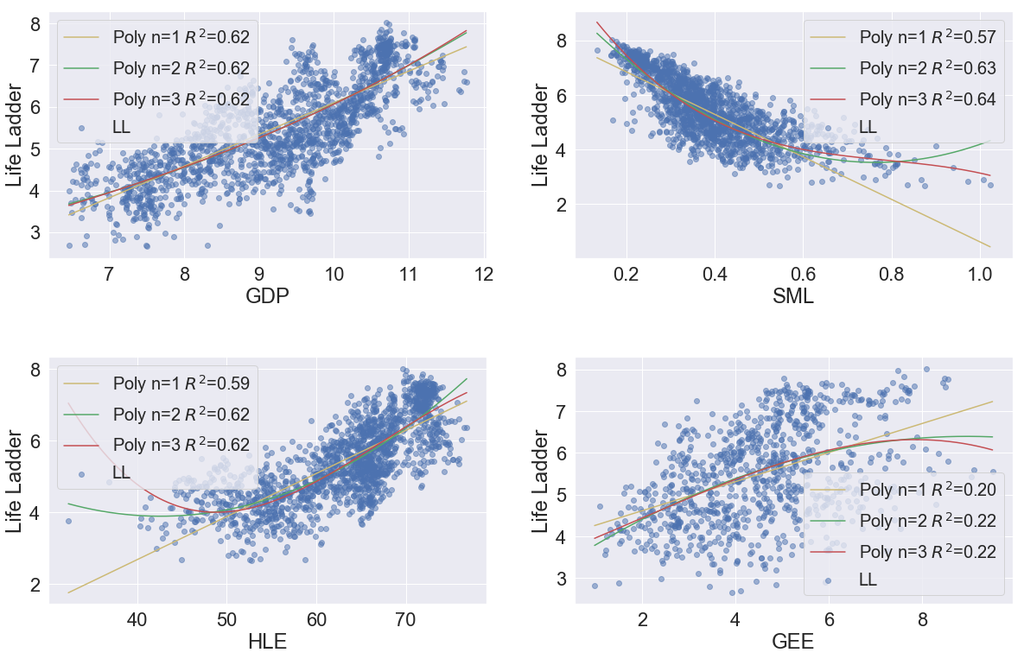

```python
visualize_regression(world_targ_predct_vars)
```

##### 4. Create subplots for every New Zealand predictor variable and fit polynomial regression lines.

Now we will look into how each predictor variable individually affects New Zealand happiness.

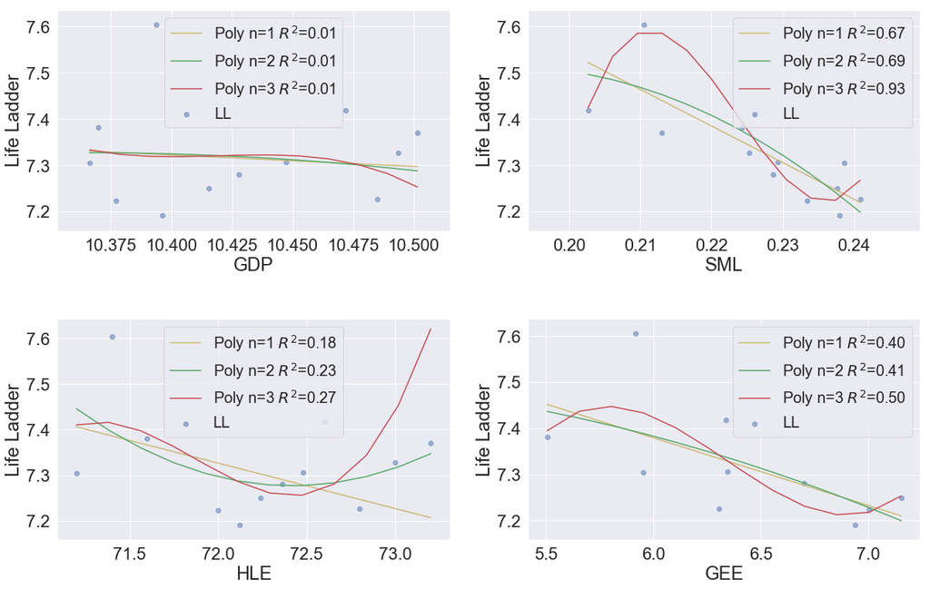

```python
visualize_regression(nz_targ_predct_vars)
```

The following scripts will interpret the model output for these two predictor values.

### World Single Regression Model

```python
poly_1, poly_2, poly_3 = regress_model(world_targ_predct_vars, 'LL', 'SML')
poly_3.summary()
```

OLS Regression Results

| Dep. Variable: | LL | R-squared: | 0.638 |
| --- | --- | --- | --- |
| Model: | OLS | Adj. R-squared: | 0.636 |
| Method: | Least Squares | F-statistic: | 538.0 |
| Date: | Fri, 28 Jun 2019 | Prob (F-statistic): | 1.36e-201 |
| Time: | 20:27:03 | Log-Likelihood: | -984.79 |
| No. Observations: | 921 | AIC: | 1978. |
| Df Residuals: | 917 | BIC: | 1997. |
| Df Model: | 3 |  |  |
| Covariance Type: | nonrobust |  |  |

|  | coef | std err | t | P>\|t\| | [0.025 | 0.975] |
| --- | --- | --- | --- | --- | --- | --- |
| Intercept | 11.8878 | 0.410 | 29.027 | 0.000 | 11.084 | 12.692 |
| SML | -28.3051 | 2.770 | -10.220 | 0.000 | -33.740 | -22.870 |
| I(SML ** 2.0) | 33.8482 | 5.804 | 5.832 | 0.000 | 22.458 | 45.238 |
| I(SML ** 3.0) | -14.2963 | 3.733 | -3.829 | 0.000 | -21.623 | -6.969 |

| Omnibus: | 37.947 | Durbin-Watson: | 0.523 |
| --- | --- | --- | --- |
| Prob(Omnibus): | 0.000 | Jarque-Bera (JB): | 41.594 |
| Skew: | -0.503 | Prob(JB): | 9.29e-10 |
| Kurtosis: | 3.271 | Cond. No. | 345. |

Warnings:  
[1] Standard Errors assume that the covariance matrix of the errors is correctly specified.

### New Zealand Single Regression Model

```python
poly_1, poly_2, poly_3 = regress_model(nz_targ_predct_vars, 'LL', 'SML')
poly_3.summary()
```

OLS Regression Results

| Dep. Variable: | LL | R-squared: | 0.926 |
| --- | --- | --- | --- |
| Model: | OLS | Adj. R-squared: | 0.888 |
| Method: | Least Squares | F-statistic: | 24.85 |
| Date: | Fri, 28 Jun 2019 | Prob (F-statistic): | 0.000879 |
| Time: | 20:27:04 | Log-Likelihood: | 20.286 |
| No. Observations: | 10 | AIC: | -32.57 |
| Df Residuals: | 6 | BIC: | -31.36 |
| Df Model: | 3 |  |  |
| Covariance Type: | nonrobust |  |  |

|  | coef | std err | t | P>\|t\| | [0.025 | 0.975] |
| --- | --- | --- | --- | --- | --- | --- |
| Intercept | -532.5727 | 123.927 | -4.297 | 0.005 | -835.810 | -229.335 |
| SML | 7286.0903 | 1674.395 | 4.351 | 0.005 | 3188.993 | 1.14e+04 |
| I(SML ** 2.0) | -3.267e+04 | 7527.003 | -4.340 | 0.005 | -5.11e+04 | -1.43e+04 |
| I(SML ** 3.0) | 4.868e+04 | 1.13e+04 | 4.324 | 0.005 | 2.11e+04 | 7.62e+04 |

| Omnibus: | 3.138 | Durbin-Watson: | 1.385 |
| --- | --- | --- | --- |
| Prob(Omnibus): | 0.208 | Jarque-Bera (JB): | 1.112 |
| Skew: | 0.812 | Prob(JB): | 0.573 |
| Kurtosis: | 3.186 | Cond. No. | 1.08e+06 |

Warnings:  
[1] Standard Errors assume that the covariance matrix of the errors is correctly specified.  
[2] The smallest eigenvalue is 9.06e-12. This might indicate that there are  
strong multicollinearity problems or that the design matrix is singular.

#### New Zealand Predictor Interpretation

We also need to consider the condition number as it is very large. As this is not a multivariable regression model, there is no chance of multicollinearity, therefore, there must be other problems with this model.

### Multiple Regression Model

Now that we have looked at single variable regression, it is important that we combine all our predictor variables into one model and see they affect our target variable.

To achieve this the following steps must be performed in order:

1. Create a multiple regression formula
2. Create a multiple regression model
3. Interpret the data

```python
def create_regress_formula(target, df):
    formula = target + ' ~ 1'
    for predictor in df.columns:
        if predictor != target:
            formula = formula + ' + ' + predictor
    return formula
```

```python
def mulitple_regression(df, target):
    formu = create_regress_formula(target, df)
    model = smf.ols(formula=formu, data=df.dropna()).fit()
    return model
```

### World Multiple Regression Model

```python
model = mulitple_regression(world_targ_predct_vars, 'LL')
model.summary()
```

OLS Regression Results

| Dep. Variable: | LL | R-squared: | 0.780 |
| --- | --- | --- | --- |
| Model: | OLS | Adj. R-squared: | 0.779 |
| Method: | Least Squares | F-statistic: | 814.0 |
| Date: | Fri, 28 Jun 2019 | Prob (F-statistic): | 9.87e-300 |
| Time: | 20:27:04 | Log-Likelihood: | -754.13 |
| No. Observations: | 921 | AIC: | 1518. |
| Df Residuals: | 916 | BIC: | 1542. |
| Df Model: | 4 |  |  |
| Covariance Type: | nonrobust |  |  |

|  | coef | std err | t | P>\|t\| | [0.025 | 0.975] |
| --- | --- | --- | --- | --- | --- | --- |
| Intercept | 1.4574 | 0.244 | 5.970 | 0.000 | 0.978 | 1.936 |
| GDP | 0.2897 | 0.032 | 9.189 | 0.000 | 0.228 | 0.352 |
| SML | -4.0479 | 0.207 | -19.580 | 0.000 | -4.454 | -3.642 |
| HLE | 0.0383 | 0.005 | 7.694 | 0.000 | 0.029 | 0.048 |
| GEE | 0.1013 | 0.013 | 7.696 | 0.000 | 0.075 | 0.127 |

| Omnibus: | 8.933 | Durbin-Watson: | 0.539 |
| --- | --- | --- | --- |
| Prob(Omnibus): | 0.011 | Jarque-Bera (JB): | 9.079 |
| Skew: | 0.232 | Prob(JB): | 0.0107 |
| Kurtosis: | 2.854 | Cond. No. | 1.08e+03 |

Warnings:  
[1] Standard Errors assume that the covariance matrix of the errors is correctly specified.  
[2] The condition number is large, 1.08e+03. This might indicate that there are  
strong multicollinearity or other numerical problems.

#### World Predictor Interpretation

The p-values for each predictor variable equal 0.000 meaning we can confidently reject the null hypothesis that the coefficients are equal to 0. This means it is likely that changes in the predictor variables relate to changes in the target variable.

The F-statistic for this model is 814.0. This is a very significant value meaning the coefficients included in this model improved the models fit.

The Adjusted R-squared value for this model is 0.779 meaning this model has a strong relationship and is good at predicting happiness.

The condition number is very large, 1.08e+03. This significantly large value might indicate strong multicollinearity. This causes an increase in the standard errors in the coefficients. This, in turn, could mean that the coefficients for some predictor variables may not be different from 0. To remedy multicollinearity, I would recommend removing highly correlated predictor variables from the model.

### New Zealand Multiple Regression Model

```python
model = mulitple_regression(nz_targ_predct_vars, 'LL')
model.summary()
```

OLS Regression Results

| Dep. Variable: | LL | R-squared: | 0.915 |
| --- | --- | --- | --- |
| Model: | OLS | Adj. R-squared: | 0.848 |
| Method: | Least Squares | F-statistic: | 13.53 |
| Date: | Fri, 28 Jun 2019 | Prob (F-statistic): | 0.00685 |
| Time: | 20:27:04 | Log-Likelihood: | 19.650 |
| No. Observations: | 10 | AIC: | -29.30 |
| Df Residuals: | 5 | BIC: | -27.79 |
| Df Model: | 4 |  |  |
| Covariance Type: | nonrobust |  |  |

|  | coef | std err | t | P>\|t\| | [0.025 | 0.975] |
| --- | --- | --- | --- | --- | --- | --- |
| Intercept | 4.7138 | 5.795 | 0.813 | 0.453 | -10.184 | 19.611 |
| GDP | 1.9856 | 1.102 | 1.802 | 0.131 | -0.847 | 4.818 |
| SML | -6.2654 | 1.438 | -4.358 | 0.007 | -9.961 | -2.570 |
| HLE | -0.2305 | 0.096 | -2.390 | 0.062 | -0.478 | 0.017 |
| GEE | -0.0050 | 0.045 | -0.111 | 0.916 | -0.121 | 0.111 |

| Omnibus: | 0.427 | Durbin-Watson: | 2.522 |
| --- | --- | --- | --- |
| Prob(Omnibus): | 0.808 | Jarque-Bera (JB): | 0.369 |
| Skew: | -0.361 | Prob(JB): | 0.831 |
| Kurtosis: | 2.396 | Cond. No. | 2.85e+04 |

Warnings:  
[1] Standard Errors assume that the covariance matrix of the errors is correctly specified.  
[2] The condition number is large, 2.85e+04. This might indicate that there are  
strong multicollinearity or other numerical problems.

#### New Zeland Predictor Interpretation

The Adjusted R-squared value for this model is 0.848 meaning this model has a strong relationship and is good at predicting happiness.

The condition number is very large, 2.85e+04. This significantly large value might indicate strong multicollinearity. This causes an increase in the standard errors in the coefficients. This, in turn, could mean that the coefficients for some predictor variables may not be different from 0. To remedy multicollinearity, I would recommend removing highly correlated predictor variables from the model.

#### Feature Selection for Multiple Regression

Now that have a working model, we need to select the right features to improve the models predictive accuracy.

The following script increases the number of features included by one, builds a model and displays the R-squared value for interpretation.

```python
headers = []
for header in WHRData.columns:
    headers.append(header)
    model = mulitple_regression(WHRData[headers], 'LL')
    print('Header added:', header, '\tR-squared:', model.rsquared)
```

```
Header added: LL 	R-squared: 0.0
Header added: GDP 	R-squared: 0.6080959180257193
Header added: SS 	R-squared: 0.6670045663224895
Header added: HLE 	R-squared: 0.6856395982752674
Header added: FLC 	R-squared: 0.7200000388796429
Header added: GEN 	R-squared: 0.7295001681946731
Header added: POC 	R-squared: 0.7370584758316641
Header added: PAF 	R-squared: 0.7576157318595211
Header added: NAF 	R-squared: 0.7577664464813532
Header added: CNG 	R-squared: 0.7712953129109984
Header added: DEQ 	R-squared: 0.7732029369622097
Header added: DLQ 	R-squared: 0.7735192449240711
Header added: SDL 	R-squared: 0.7745406135575414
Header added: SML 	R-squared: 0.9377172812113145
Header added: GI1 	R-squared: 0.9602644502024822
Header added: GI2 	R-squared: 0.9603472985609662
Header added: GHI 	R-squared: 0.9605267847008216
Header added: PTG 	R-squared: 0.9742170985047724
Header added: PT1 	R-squared: 1.0
Header added: PT2 	R-squared: 1.0
Header added: PT3 	R-squared: 1.0
Header added: PT4 	R-squared: 1.0
Header added: PT5 	R-squared: 1.0
Header added: PT6 	R-squared: 1.0
Header added: CO2 	R-squared: 1.0
Header added: GEE 	R-squared: 1.0
Header added: EPR 	R-squared: 1.0
Header added: SET 	R-squared: 1.0
Header added: POP 	R-squared: 1.0
```

After examining the output, we can see that by including the first 19 predictor variables, the model is able to predict 100% of the changes in the target variable 'Life Ladder'. This is concerning as a model that can perfectly predict our target variable usually cant. This could be caused by dropping the NaN values from the predictor variable which reduces the number of observations. We can prove this by looking at the summaries for each of the predictors added.

```python
model = mulitple_regression(WHRData.iloc[:,:14], 'LL')
print(model.summary())
model = mulitple_regression(WHRData.iloc[:,:16], 'LL')
print(model.summary())
model = mulitple_regression(WHRData.iloc[:,:18], 'LL')
print(model.summary())
model = mulitple_regression(WHRData.iloc[:,:20], 'LL')
print(model.summary())
```

```
                            OLS Regression Results
==============================================================================
Dep. Variable:                     LL   R-squared:                       0.938
Model:                            OLS   Adj. R-squared:                  0.937
Method:                 Least Squares   F-statistic:                     1491.
Date:                Fri, 28 Jun 2019   Prob (F-statistic):               0.00
Time:                        20:27:05   Log-Likelihood:                -221.71
No. Observations:                1301   AIC:                             471.4
Df Residuals:                    1287   BIC:                             543.8
Df Model:                          13
Covariance Type:            nonrobust
==============================================================================
                 coef    std err          t      P>|t|      [0.025      0.975]
------------------------------------------------------------------------------
Intercept      4.4431      0.173     25.730      0.000       4.104       4.782
GDP            0.0940      0.017      5.548      0.000       0.061       0.127
SS             0.2777      0.107      2.585      0.010       0.067       0.488
HLE           -0.0014      0.002     -0.678      0.498      -0.006       0.003
FLC            0.3075      0.094      3.276      0.001       0.123       0.492
GEN            0.3791      0.059      6.372      0.000       0.262       0.496
POC           -0.8694      0.066    -13.145      0.000      -0.999      -0.740
PAF            0.5136      0.110      4.660      0.000       0.297       0.730
NAF            0.5833      0.133      4.383      0.000       0.322       0.844
CNG           -0.3087      0.061     -5.095      0.000      -0.428      -0.190
DEQ            0.0123      0.022      0.558      0.577      -0.031       0.056
DLQ            0.0969      0.026      3.771      0.000       0.046       0.147
SDL            1.8754      0.043     43.170      0.000       1.790       1.961
SML           -9.5479      0.164    -58.068      0.000      -9.870      -9.225
==============================================================================
Omnibus:                      450.438   Durbin-Watson:                   0.643
Prob(Omnibus):                  0.000   Jarque-Bera (JB):             3973.100
Skew:                           1.350   Prob(JB):                         0.00
Kurtosis:                      11.125   Cond. No.                     1.76e+03
==============================================================================

Warnings:
[1] Standard Errors assume that the covariance matrix of the errors is correctly specified.
[2] The condition number is large, 1.76e+03. This might indicate that there are
strong multicollinearity or other numerical problems.
                            OLS Regression Results
```

[output cut: 112 more lines]

```
GI2            0.0188        inf          0        nan         nan         nan
GHI            0.0726        inf          0        nan         nan         nan
PTG            0.0850        inf          0        nan         nan         nan
PT1           -0.1134        inf         -0        nan         nan         nan
PT2            0.1071        inf          0        nan         nan         nan
==============================================================================
Omnibus:                          nan   Durbin-Watson:                   0.083
Prob(Omnibus):                    nan   Jarque-Bera (JB):                0.458
Skew:                          -0.595   Prob(JB):                        0.795
Kurtosis:                       1.500   Cond. No.                         759.
==============================================================================

Warnings:
[1] Standard Errors assume that the covariance matrix of the errors is correctly specified.
[2] The input rank is higher than the number of observations.
```

From the output above we see the No. Observations decrease as we add more variables to the model. This causes a high R-squared value. Therefore, it is important to choose a number of predictors that give good predictability and a large number of observations.

As a result, I will be selecting the first 14 predictor variables from the dataset to use in the multiple regression model as it gives a high R-squared value will providing a large number of observations.

### Final Model

The final model selected for prediction is a multiple regression model constructed using the first fourteen prediction variables of the 'WHRData' data set.

```python
model = mulitple_regression(WHRData.iloc[:,:14], 'LL')
model.summary()
```

OLS Regression Results

| Dep. Variable: | LL | R-squared: | 0.938 |
| --- | --- | --- | --- |
| Model: | OLS | Adj. R-squared: | 0.937 |
| Method: | Least Squares | F-statistic: | 1491. |
| Date: | Fri, 28 Jun 2019 | Prob (F-statistic): | 0.00 |
| Time: | 20:27:05 | Log-Likelihood: | -221.71 |
| No. Observations: | 1301 | AIC: | 471.4 |
| Df Residuals: | 1287 | BIC: | 543.8 |
| Df Model: | 13 |  |  |
| Covariance Type: | nonrobust |  |  |

|  | coef | std err | t | P>\|t\| | [0.025 | 0.975] |
| --- | --- | --- | --- | --- | --- | --- |
| Intercept | 4.4431 | 0.173 | 25.730 | 0.000 | 4.104 | 4.782 |
| GDP | 0.0940 | 0.017 | 5.548 | 0.000 | 0.061 | 0.127 |
| SS | 0.2777 | 0.107 | 2.585 | 0.010 | 0.067 | 0.488 |
| HLE | -0.0014 | 0.002 | -0.678 | 0.498 | -0.006 | 0.003 |
| FLC | 0.3075 | 0.094 | 3.276 | 0.001 | 0.123 | 0.492 |
| GEN | 0.3791 | 0.059 | 6.372 | 0.000 | 0.262 | 0.496 |
| POC | -0.8694 | 0.066 | -13.145 | 0.000 | -0.999 | -0.740 |
| PAF | 0.5136 | 0.110 | 4.660 | 0.000 | 0.297 | 0.730 |
| NAF | 0.5833 | 0.133 | 4.383 | 0.000 | 0.322 | 0.844 |
| CNG | -0.3087 | 0.061 | -5.095 | 0.000 | -0.428 | -0.190 |
| DEQ | 0.0123 | 0.022 | 0.558 | 0.577 | -0.031 | 0.056 |
| DLQ | 0.0969 | 0.026 | 3.771 | 0.000 | 0.046 | 0.147 |
| SDL | 1.8754 | 0.043 | 43.170 | 0.000 | 1.790 | 1.961 |
| SML | -9.5479 | 0.164 | -58.068 | 0.000 | -9.870 | -9.225 |

| Omnibus: | 450.438 | Durbin-Watson: | 0.643 |
| --- | --- | --- | --- |
| Prob(Omnibus): | 0.000 | Jarque-Bera (JB): | 3973.100 |
| Skew: | 1.350 | Prob(JB): | 0.00 |
| Kurtosis: | 11.125 | Cond. No. | 1.76e+03 |

Warnings:  
[1] Standard Errors assume that the covariance matrix of the errors is correctly specified.  
[2] The condition number is large, 1.76e+03. This might indicate that there are  
strong multicollinearity or other numerical problems.

The R-squared value explains 93% of the variance in the model.

We can see that SDL are significant in predicting the level of happiness. With a coefficient of 1.875, as SDL increases by 1, the target variable 'Life Ladder' increases by 1.875. The other significant predictor is SML, we can see that as SML increases by one, 'Life Ladder' decreases by -9.5479. Finally, the 4.4431 intercept means that when all predictor variables are set to 0, the base level of 'Life Ladder' will equal 4.4431.

#### Residual Plot

To calculate the residuals we must first produce the model.

```python
def residual_plot(df, target, predictors, model):
    Y_pred = model.predict(df[predictors])
    residual = df[target].values-Y_pred
    plt.figure(figsize=[10,10])
    plt.scatter(df[target],residual, alpha=0.6)
    plt.xlabel(target)
    plt.ylabel("residual")
    plt.show()
```

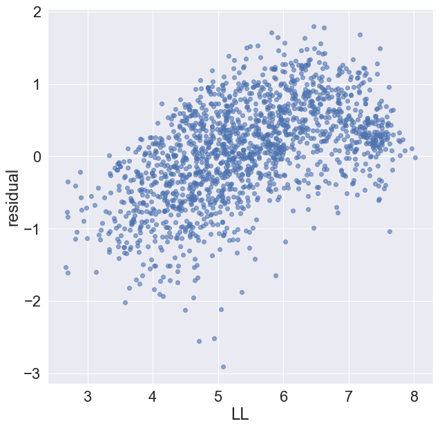

```python
poly_1, poly_2, poly_3 = regress_model(world_targ_predct_vars, 'LL', 'SML')
residual_plot(world_targ_predct_vars, 'LL', 'SML', poly_3)
```

A visual examination of the single variable residual plot does not show linearity. Instead, we see a slight right open fanning. What we would expect to see if random scatter. This represents non-homoscedastic residuals. This indicates that this model may not be appropriate.

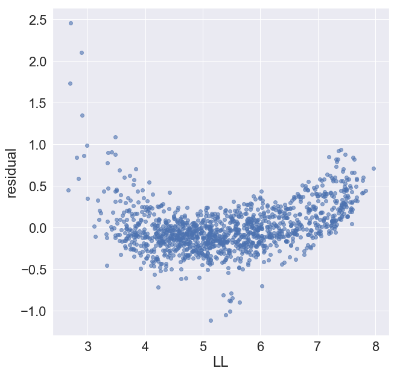

```python
model = mulitple_regression(WHRData.iloc[:,:14], 'LL')
residual_plot(WHRData.iloc[:,:14], 'LL', WHRData.iloc[:,1:14].columns, model)
```

```python
WHRData.iloc[:,:14]
```

| Country name | Year | LL | GDP | SS | HLE | FLC | GEN | POC | PAF | NAF | CNG | DEQ | DLQ | SDL | SML |
| --- | --- | --- | --- | --- | --- | --- | --- | --- | --- | --- | --- | --- | --- | --- | --- |
| Afghanistan | 2008 | 3.723590 | 7.168690 | 0.450662 | 50.799999 | 0.718114 | 0.177889 | 0.881686 | 0.517637 | 0.258195 | 0.612072 | -1.929690 | -1.655084 | 1.774662 | 0.476600 |
|  | 2009 | 4.401778 | 7.333790 | 0.552308 | 51.200001 | 0.678896 | 0.200178 | 0.850035 | 0.583926 | 0.237092 | 0.611545 | -2.044093 | -1.635025 | 1.722688 | 0.391362 |
|  | 2010 | 4.758381 | 7.386629 | 0.539075 | 51.599998 | 0.600127 | 0.134353 | 0.706766 | 0.618265 | 0.275324 | 0.299357 | -1.991810 | -1.617176 | 1.878622 | 0.394803 |
|  | 2011 | 3.831719 | 7.415019 | 0.521104 | 51.919998 | 0.495901 | 0.172137 | 0.731109 | 0.611387 | 0.267175 | 0.307386 | -1.919018 | -1.616221 | 1.785360 | 0.465942 |
|  | 2012 | 3.782938 | 7.517126 | 0.520637 | 52.240002 | 0.530935 | 0.244273 | 0.775620 | 0.710385 | 0.267919 | 0.435440 | -1.842996 | -1.404078 | 1.798283 | 0.475367 |
|  | 2013 | 3.572100 | 7.522238 | 0.483552 | 52.560001 | 0.577955 | 0.070403 | 0.823204 | 0.620585 | 0.273328 | 0.482847 | -1.879709 | -1.403036 | 1.223690 | 0.342569 |
|  | 2014 | 3.130896 | 7.516955 | 0.525568 | 52.880001 | 0.508514 | 0.113184 | 0.871242 | 0.531691 | 0.374861 | 0.409048 | -1.773257 | -1.312503 | 1.395396 | 0.445686 |
|  | 2015 | 3.982855 | 7.500539 | 0.528597 | 53.200001 | 0.388928 | 0.089091 | 0.880638 | 0.553553 | 0.339276 | 0.260557 | -1.844364 | -1.291594 | 2.160618 | 0.542480 |
|  | 2016 | 4.220169 | 7.497038 | 0.559072 | 53.000000 | 0.522566 | 0.051365 | 0.793246 | 0.564953 | 0.348332 | 0.324990 | -1.855426 | -1.392713 | 1.796219 | 0.425627 |
|  | 2017 | 2.661718 | 7.497755 | 0.490880 | 52.799999 | 0.427011 | -0.112198 | 0.954393 | 0.496349 | 0.371326 | 0.261179 | -1.886566 | -1.437808 | 1.454051 | 0.546283 |
|  | 2018 | 2.694303 | 7.494588 | 0.507516 | 52.599998 | 0.373536 | -0.084888 | 0.927606 | 0.424125 | 0.404904 | 0.364666 | NaN | NaN | 1.408344 | 0.522712 |
| Albania | 2007 | 4.634252 | 9.077331 | 0.821372 | 65.800003 | 0.528605 | -0.014393 | 0.874700 | 0.552678 | 0.246335 | 0.300681 | -0.045108 | -0.420024 | 1.764947 | 0.380848 |
|  | 2009 | 5.485470 | 9.161638 | 0.833047 | 66.199997 | 0.525223 | -0.160855 | 0.863665 | 0.640024 | 0.279257 | NaN | 0.048114 | -0.264635 | 1.919640 | 0.349950 |
|  | 2010 | 5.268937 | 9.203032 | 0.733152 | 66.400002 | 0.568958 | -0.175367 | 0.726262 | 0.647908 | 0.300060 | NaN | -0.033831 | -0.246433 | 1.862201 | 0.353430 |
|  | 2011 | 5.867422 | 9.230904 | 0.759434 | 66.680000 | 0.487496 | -0.207943 | 0.877003 | 0.627659 | 0.256577 | NaN | -0.110023 | -0.278413 | 1.845783 | 0.314582 |
|  | 2012 | 5.510124 | 9.246655 | 0.784502 | 66.959999 | 0.601512 | -0.172262 | 0.847675 | 0.606636 | 0.271393 | 0.364894 | -0.060784 | -0.328862 | 1.921203 | 0.348668 |
|  | 2013 | 4.550648 | 9.258445 | 0.759477 | 67.239998 | 0.631830 | -0.130645 | 0.862905 | 0.633609 | 0.338379 | 0.338095 | 0.070411 | -0.330956 | 2.315580 | 0.508846 |
|  | 2014 | 4.813763 | 9.278104 | 0.625587 | 67.519997 | 0.734648 | -0.028162 | 0.882704 | 0.684911 | 0.334543 | 0.498786 | 0.314873 | -0.187407 | 2.660069 | 0.552597 |
|  | 2015 | 4.606651 | 9.302960 | 0.639356 | 67.800003 | 0.703851 | -0.084411 | 0.884793 | 0.688370 | 0.350427 | 0.506978 | 0.251629 | -0.152544 | 2.729001 | 0.592405 |
|  | 2016 | 4.511101 | 9.337532 | 0.638411 | 68.099998 | 0.729819 | -0.020687 | 0.901071 | 0.675244 | 0.321706 | 0.400910 | 0.257292 | -0.134950 | 2.646668 | 0.586701 |
|  | 2017 | 4.639548 | 9.376145 | 0.637698 | 68.400002 | 0.749611 | -0.032643 | 0.876135 | 0.669241 | 0.333884 | 0.457738 | 0.299945 | -0.130315 | 2.682105 | 0.578096 |
|  | 2018 | 5.004403 | 9.412399 | 0.683592 | 68.699997 | 0.824212 | 0.005385 | 0.899129 | 0.713300 | 0.318997 | 0.435338 | NaN | NaN | 2.640531 | 0.527642 |
| Algeria | 2010 | 5.463567 | 9.462701 | NaN | 64.500000 | 0.592696 | -0.229078 | 0.618038 | NaN | NaN | NaN | -1.140853 | -0.740093 | 1.626279 | 0.297659 |
|  | 2011 | 5.317194 | 9.471962 | 0.810234 | 64.660004 | 0.529561 | -0.204406 | 0.637982 | 0.550203 | 0.254897 | NaN | -1.182341 | -0.776610 | 1.660421 | 0.312274 |
|  | 2012 | 5.604596 | 9.485086 | 0.839397 | 64.820000 | 0.586663 | -0.195859 | 0.690116 | 0.604023 | 0.229716 | NaN | -1.115535 | -0.771172 | 1.939237 | 0.346008 |
|  | 2014 | 6.354898 | 9.509210 | 0.818189 | 65.139999 | NaN | NaN | NaN | 0.625905 | 0.176866 | NaN | -1.002867 | -0.783428 | 1.632461 | 0.256882 |
|  | 2016 | 5.340854 | 9.541166 | 0.748588 | 65.500000 | NaN | NaN | NaN | 0.660510 | 0.377112 | NaN | -0.976652 | -0.815911 | 2.114553 | 0.395920 |
|  | 2017 | 5.248912 | 9.540639 | 0.806754 | 65.699997 | 0.436670 | -0.191522 | 0.699774 | 0.641980 | 0.288710 | NaN | -0.927691 | -0.816839 | 2.039765 | 0.388607 |
|  | 2018 | 5.043086 | 9.557952 | 0.798651 | 65.900002 | 0.583381 | -0.172413 | 0.758704 | 0.591043 | 0.292946 | NaN | NaN | NaN | 1.973943 | 0.391416 |
| Angola | 2011 | 5.589001 | 8.684613 | 0.723094 | 52.500000 | 0.583702 | 0.065088 | 0.911320 | 0.658647 | 0.361063 | 0.232387 | -0.747358 | -1.215250 | 2.212474 | 0.395862 |
| ... | ... | ... | ... | ... | ... | ... | ... | ... | ... | ... | ... | ... | ... | ... | ... |
| Yemen | 2014 | 3.967958 | 8.233982 | 0.638252 | 54.299999 | 0.663909 | -0.173103 | 0.885429 | 0.610585 | 0.275674 | 0.344929 | -1.983291 | -1.264091 | 2.438403 | 0.614523 |
|  | 2015 | 2.982674 | 7.744412 | 0.668683 | 54.299999 | 0.609981 | -0.137216 | 0.829098 | 0.507435 | 0.321357 | 0.263297 | -2.101797 | -1.374387 | 2.194034 | 0.735593 |
|  | 2016 | 3.825631 | 7.299221 | 0.775407 | 55.099998 | 0.532964 | -0.125668 | NaN | 0.469345 | 0.227925 | 0.267581 | -2.243389 | -1.654798 | 2.105525 | 0.550373 |
|  | 2017 | 3.253560 | NaN | 0.789555 | 55.900002 | 0.595191 | NaN | NaN | 0.455182 | 0.295064 | 0.247787 | -2.326562 | -1.678789 | 2.178544 | 0.669588 |
|  | 2018 | 3.057514 | NaN | 0.789422 | 56.700001 | 0.552726 | NaN | 0.792587 | 0.461114 | 0.314870 | 0.308151 | NaN | NaN | 2.402008 | 0.785608 |
| Zambia | 2006 | 4.824455 | 7.866006 | 0.797665 | 44.259998 | 0.720972 | -0.015756 | 0.785281 | 0.700788 | 0.226278 | 0.526590 | 0.077581 | -0.642004 | 1.893255 | 0.392429 |
|  | 2007 | 3.998293 | 7.918941 | 0.687989 | 45.720001 | 0.682005 | -0.076854 | 0.947914 | 0.686748 | 0.245637 | 0.404140 | 0.078216 | -0.536810 | 1.791168 | 0.447983 |
|  | 2008 | 4.730263 | 7.966175 | 0.624418 | 47.180000 | 0.716994 | 0.045704 | 0.890299 | 0.744144 | 0.205723 | 0.557462 | 0.154371 | -0.499575 | 1.869401 | 0.395200 |
|  | 2009 | 5.260361 | 8.026193 | 0.781926 | 48.639999 | 0.696183 | -0.106159 | 0.916553 | 0.727505 | 0.122659 | 0.413418 | 0.133997 | -0.567933 | 1.889908 | 0.359273 |
|  | 2011 | 4.999114 | 8.120028 | 0.864023 | 50.840000 | 0.662850 | -0.007741 | 0.882150 | 0.833214 | 0.204070 | 0.397613 | 0.169676 | -0.487765 | 1.729702 | 0.346002 |
|  | 2012 | 5.013375 | 8.163204 | 0.780023 | 51.580002 | 0.787760 | -0.003085 | 0.806394 | 0.725965 | 0.250368 | 0.594114 | 0.264068 | -0.388092 | 2.200456 | 0.438917 |
|  | 2013 | 5.243996 | 8.182191 | 0.761312 | 52.320000 | 0.769912 | -0.115299 | 0.732268 | 0.734979 | 0.307960 | 0.552761 | 0.164946 | -0.385220 | 2.562254 | 0.488607 |
|  | 2014 | 4.345837 | 8.197678 | 0.706223 | 53.060001 | 0.811825 | -0.021717 | 0.808841 | 0.692035 | 0.327384 | 0.606339 | 0.023306 | -0.395449 | 2.521534 | 0.580218 |
|  | 2015 | 4.843164 | 8.196217 | 0.691483 | 53.799999 | 0.758654 | -0.049828 | 0.871020 | 0.690034 | 0.381731 | 0.631103 | 0.040718 | -0.391482 | 3.080448 | 0.636040 |
|  | 2016 | 4.347544 | 8.203072 | 0.767047 | 54.299999 | 0.811575 | 0.111332 | 0.770644 | 0.730680 | 0.372241 | 0.696892 | -0.083534 | -0.460275 | 3.197226 | 0.735410 |
|  | 2017 | 3.932777 | 8.213179 | 0.743754 | 54.799999 | 0.823169 | 0.128904 | 0.739541 | 0.684623 | 0.387189 | 0.717004 | -0.114061 | -0.488385 | 2.650283 | 0.673896 |
|  | 2018 | 4.041488 | 8.223958 | 0.717720 | 55.299999 | 0.790626 | 0.036644 | 0.810731 | 0.702698 | 0.350963 | 0.606715 | NaN | NaN | 2.783419 | 0.688711 |
| Zimbabwe | 2006 | 3.826268 | 7.366704 | 0.821656 | 41.580002 | 0.431110 | -0.056554 | 0.904757 | 0.715229 | 0.297147 | 0.317073 | -1.236102 | -1.570760 | 2.013538 | 0.526241 |
|  | 2007 | 3.280247 | 7.313939 | 0.828113 | 42.860001 | 0.455957 | -0.061563 | 0.946287 | 0.660861 | 0.264989 | 0.225752 | -1.340245 | -1.653740 | 1.929571 | 0.588240 |
|  | 2008 | 3.174264 | 7.102516 | 0.843475 | 44.139999 | 0.343556 | -0.068002 | 0.963846 | 0.630983 | 0.250060 | 0.181594 | -1.381488 | -1.701545 | 1.685007 | 0.530834 |
|  | 2009 | 4.055914 | 7.197595 | 0.805781 | 45.419998 | 0.411089 | -0.055836 | 0.930818 | 0.735503 | 0.218419 | 0.285287 | -1.353181 | -1.717821 | 2.024098 | 0.499048 |
|  | 2010 | 4.681570 | 7.296330 | 0.856638 | 46.700001 | 0.664718 | -0.066457 | 0.828361 | 0.747702 | 0.122150 | 0.471201 | -1.289599 | -1.693678 | 1.511014 | 0.322758 |
|  | 2011 | 4.845642 | 7.418864 | 0.864694 | 48.119999 | 0.632978 | -0.062267 | 0.829800 | 0.781189 | 0.210544 | 0.425926 | -1.204545 | -1.621979 | 1.760146 | 0.363243 |
|  | 2012 | 4.955101 | 7.534424 | 0.896476 | 49.540001 | 0.469531 | -0.075712 | 0.858691 | 0.669279 | 0.177311 | 0.407084 | -1.125315 | -1.555728 | 1.853195 | 0.373997 |
|  | 2013 | 4.690188 | 7.565154 | 0.799274 | 50.959999 | 0.575884 | -0.079458 | 0.830937 | 0.711885 | 0.182288 | 0.527755 | -1.026085 | -1.526321 | 1.964805 | 0.418918 |
|  | 2014 | 4.184451 | 7.562753 | 0.765839 | 52.380001 | 0.642034 | -0.048634 | 0.820217 | 0.725214 | 0.239111 | 0.566209 | -0.985267 | -1.484067 | 2.079248 | 0.496899 |
|  | 2015 | 3.703191 | 7.556052 | 0.735800 | 53.799999 | 0.667193 | -0.097354 | 0.810457 | 0.715079 | 0.178861 | 0.590012 | -0.893078 | -1.357514 | 2.198865 | 0.593776 |
|  | 2016 | 3.735400 | 7.538829 | 0.768425 | 54.400002 | 0.732971 | -0.068105 | 0.723612 | 0.737636 | 0.208555 | 0.699344 | -0.900649 | -1.374650 | 2.776363 | 0.743257 |
|  | 2017 | 3.638300 | 7.549491 | 0.754147 | 55.000000 | 0.752826 | -0.069670 | 0.751208 | 0.806428 | 0.224051 | 0.682647 | -0.988153 | -1.350867 | 2.656848 | 0.730244 |
|  | 2018 | 3.616480 | 7.553395 | 0.775388 | 55.599998 | 0.762675 | -0.038384 | 0.844209 | 0.710119 | 0.211726 | 0.550508 | NaN | NaN | 2.498696 | 0.690919 |

1663 rows × 14 columns

```python
WHRData
```

| Country name | Year | LL | GDP | SS | HLE | FLC | GEN | POC | PAF | NAF | CNG | ... | PT2 | PT3 | PT4 | PT5 | PT6 | CO2 | GEE | EPR | SET | POP |
| --- | --- | --- | --- | --- | --- | --- | --- | --- | --- | --- | --- | --- | --- | --- | --- | --- | --- | --- | --- | --- | --- | --- |
| Afghanistan | 2008 | 3.723590 | 7.168690 | 0.450662 | 50.799999 | 0.718114 | 0.177889 | 0.881686 | 0.517637 | 0.258195 | 0.612072 | ... | NaN | NaN | NaN | NaN | NaN | 0.151721 | NaN | 61.960999 | NaN | 27722276.0 |
|  | 2009 | 4.401778 | 7.333790 | 0.552308 | 51.200001 | 0.678896 | 0.200178 | 0.850035 | 0.583926 | 0.237092 | 0.611545 | ... | NaN | NaN | NaN | NaN | NaN | 0.238399 | NaN | 61.806999 | 3.817950 | 28394813.0 |
|  | 2010 | 4.758381 | 7.386629 | 0.539075 | 51.599998 | 0.600127 | 0.134353 | 0.706766 | 0.618265 | 0.275324 | 0.299357 | ... | NaN | NaN | NaN | NaN | NaN | 0.289988 | 3.46196 | 61.851002 | NaN | 29185507.0 |
|  | 2011 | 3.831719 | 7.415019 | 0.521104 | 51.919998 | 0.495901 | 0.172137 | 0.731109 | 0.611387 | 0.267175 | 0.307386 | ... | NaN | NaN | NaN | NaN | NaN | 0.406424 | 3.43785 | 62.280998 | 3.679700 | 30117413.0 |
|  | 2012 | 3.782938 | 7.517126 | 0.520637 | 52.240002 | 0.530935 | 0.244273 | 0.775620 | 0.710385 | 0.267919 | 0.435440 | ... | NaN | NaN | NaN | NaN | NaN | 0.345149 | 2.52441 | 62.813999 | NaN | 31161376.0 |
|  | 2013 | 3.572100 | 7.522238 | 0.483552 | 52.560001 | 0.577955 | 0.070403 | 0.823204 | 0.620585 | 0.273328 | 0.482847 | ... | NaN | NaN | NaN | NaN | NaN | 0.310341 | 3.43437 | 63.213001 | NaN | 32269589.0 |
|  | 2014 | 3.130896 | 7.516955 | 0.525568 | 52.880001 | 0.508514 | 0.113184 | 0.871242 | 0.531691 | 0.374861 | 0.409048 | ... | NaN | NaN | NaN | NaN | NaN | 0.293946 | 3.67390 | 63.665001 | 8.475700 | 33370794.0 |
|  | 2015 | 3.982855 | 7.500539 | 0.528597 | 53.200001 | 0.388928 | 0.089091 | 0.880638 | 0.553553 | 0.339276 | 0.260557 | ... | NaN | NaN | NaN | NaN | NaN | NaN | 3.24202 | 64.172997 | NaN | 34413603.0 |
|  | 2016 | 4.220169 | 7.497038 | 0.559072 | 53.000000 | 0.522566 | 0.051365 | 0.793246 | 0.564953 | 0.348332 | 0.324990 | ... | NaN | NaN | NaN | NaN | NaN | NaN | 4.20525 | 64.511002 | NaN | 35383128.0 |
|  | 2017 | 2.661718 | 7.497755 | 0.490880 | 52.799999 | 0.427011 | -0.112198 | 0.954393 | 0.496349 | 0.371326 | 0.261179 | ... | NaN | NaN | NaN | NaN | NaN | NaN | 3.92675 | 64.858002 | NaN | 36296400.0 |
|  | 2018 | 2.694303 | 7.494588 | 0.507516 | 52.599998 | 0.373536 | -0.084888 | 0.927606 | 0.424125 | 0.404904 | 0.364666 | ... | NaN | NaN | NaN | NaN | NaN | NaN | NaN | 64.939003 | 9.992140 | NaN |
| Albania | 2007 | 4.634252 | 9.077331 | 0.821372 | 65.800003 | 0.528605 | -0.014393 | 0.874700 | 0.552678 | 0.246335 | 0.300681 | ... | NaN | 0.243243 | 0.232000 | NaN | NaN | 1.322335 | 3.26868 | 46.993999 | 30.876390 | 2970017.0 |
|  | 2009 | 5.485470 | 9.161638 | 0.833047 | 66.199997 | 0.525223 | -0.160855 | 0.863665 | 0.640024 | 0.279257 | NaN | ... | NaN | 0.243243 | 0.232000 | NaN | NaN | 1.495600 | NaN | 47.077000 | 33.630871 | 2927519.0 |
|  | 2010 | 5.268937 | 9.203032 | 0.733152 | 66.400002 | 0.568958 | -0.175367 | 0.726262 | 0.647908 | 0.300060 | NaN | ... | NaN | 0.243243 | 0.232000 | NaN | NaN | 1.578574 | NaN | 46.625999 | 44.874630 | 2913021.0 |
|  | 2011 | 5.867422 | 9.230904 | 0.759434 | 66.680000 | 0.487496 | -0.207943 | 0.877003 | 0.627659 | 0.256577 | NaN | ... | NaN | 0.243243 | 0.232000 | NaN | NaN | 1.803715 | NaN | 48.203999 | 50.198372 | 2905195.0 |
|  | 2012 | 5.510124 | 9.246655 | 0.784502 | 66.959999 | 0.601512 | -0.172262 | 0.847675 | 0.606636 | 0.271393 | 0.364894 | ... | NaN | 0.243243 | 0.232000 | NaN | NaN | 1.692908 | NaN | 49.759998 | 61.446629 | 2900401.0 |
|  | 2013 | 4.550648 | 9.258445 | 0.759477 | 67.239998 | 0.631830 | -0.130645 | 0.862905 | 0.633609 | 0.338379 | 0.338095 | ... | NaN | 0.243243 | 0.232000 | NaN | NaN | 1.749211 | 3.53930 | 45.139999 | 68.078232 | 2895092.0 |
|  | 2014 | 4.813763 | 9.278104 | 0.625587 | 67.519997 | 0.734648 | -0.028162 | 0.882704 | 0.684911 | 0.334543 | 0.498786 | ... | NaN | 0.243243 | 0.232000 | NaN | NaN | 1.978763 | NaN | 44.851002 | 70.345863 | 2889104.0 |
|  | 2015 | 4.606651 | 9.302960 | 0.639356 | 67.800003 | 0.703851 | -0.084411 | 0.884793 | 0.688370 | 0.350427 | 0.506978 | ... | NaN | 0.243243 | 0.232000 | NaN | NaN | NaN | 3.43797 | 46.808998 | 66.402893 | 2880703.0 |
|  | 2016 | 4.511101 | 9.337532 | 0.638411 | 68.099998 | 0.729819 | -0.020687 | 0.901071 | 0.675244 | 0.321706 | 0.400910 | ... | NaN | 0.243243 | 0.232000 | NaN | NaN | NaN | 3.95464 | 47.724998 | 61.213799 | 2876101.0 |
|  | 2017 | 4.639548 | 9.376145 | 0.637698 | 68.400002 | 0.749611 | -0.032643 | 0.876135 | 0.669241 | 0.333884 | 0.457738 | ... | NaN | 0.243243 | 0.232000 | NaN | NaN | NaN | NaN | 48.458000 | 56.975010 | 2873457.0 |
|  | 2018 | 5.004403 | 9.412399 | 0.683592 | 68.699997 | 0.824212 | 0.005385 | 0.899129 | 0.713300 | 0.318997 | 0.435338 | ... | NaN | 0.243243 | 0.232000 | NaN | NaN | NaN | NaN | 48.269001 | NaN | NaN |
| Algeria | 2010 | 5.463567 | 9.462701 | NaN | 64.500000 | 0.592696 | -0.229078 | 0.618038 | NaN | NaN | NaN | ... | NaN | NaN | 0.107644 | NaN | 0.179286 | 3.312561 | NaN | 38.143002 | 29.769529 | 35977455.0 |
|  | 2011 | 5.317194 | 9.471962 | 0.810234 | 64.660004 | 0.529561 | -0.204406 | 0.637982 | 0.550203 | 0.254897 | NaN | ... | NaN | NaN | 0.107644 | NaN | 0.179286 | 3.305571 | NaN | 38.272999 | 31.126711 | 36661444.0 |
|  | 2012 | 5.604596 | 9.485086 | 0.839397 | 64.820000 | 0.586663 | -0.195859 | 0.690116 | 0.604023 | 0.229716 | NaN | ... | NaN | NaN | 0.107644 | NaN | 0.179286 | 3.477108 | NaN | 38.000000 | 32.146320 | 37383887.0 |
|  | 2014 | 6.354898 | 9.509210 | 0.818189 | 65.139999 | NaN | NaN | NaN | 0.625905 | 0.176866 | NaN | ... | NaN | NaN | 0.107644 | NaN | 0.179286 | 3.735520 | NaN | 37.278999 | 34.498138 | 38923687.0 |
|  | 2016 | 5.340854 | 9.541166 | 0.748588 | 65.500000 | NaN | NaN | NaN | 0.660510 | 0.377112 | NaN | ... | NaN | NaN | 0.107644 | NaN | 0.179286 | NaN | NaN | 37.183998 | 42.663689 | 40551404.0 |
|  | 2017 | 5.248912 | 9.540639 | 0.806754 | 65.699997 | 0.436670 | -0.191522 | 0.699774 | 0.641980 | 0.288710 | NaN | ... | NaN | NaN | 0.107644 | NaN | 0.179286 | NaN | NaN | 36.408001 | 47.720928 | 41389198.0 |
|  | 2018 | 5.043086 | 9.557952 | 0.798651 | 65.900002 | 0.583381 | -0.172413 | 0.758704 | 0.591043 | 0.292946 | NaN | ... | NaN | NaN | 0.107644 | NaN | 0.179286 | NaN | NaN | 36.299999 | NaN | NaN |
| Angola | 2011 | 5.589001 | 8.684613 | 0.723094 | 52.500000 | 0.583702 | 0.065088 | 0.911320 | 0.658647 | 0.361063 | 0.232387 | ... | NaN | NaN | NaN | NaN | NaN | 1.252681 | NaN | 72.132004 | 6.247280 | 24220661.0 |
| ... | ... | ... | ... | ... | ... | ... | ... | ... | ... | ... | ... | ... | ... | ... | ... | ... | ... | ... | ... | ... | ... | ... |
| Yemen | 2014 | 3.967958 | 8.233982 | 0.638252 | 54.299999 | 0.663909 | -0.173103 | 0.885429 | 0.610585 | 0.275674 | 0.344929 | ... | NaN | NaN | NaN | NaN | 0.385000 | 0.878996 | NaN | 31.976999 | NaN | 25823485.0 |
|  | 2015 | 2.982674 | 7.744412 | 0.668683 | 54.299999 | 0.609981 | -0.137216 | 0.829098 | 0.507435 | 0.321357 | 0.263297 | ... | NaN | NaN | NaN | NaN | 0.385000 | NaN | NaN | 32.316002 | NaN | 26497889.0 |
|  | 2016 | 3.825631 | 7.299221 | 0.775407 | 55.099998 | 0.532964 | -0.125668 | NaN | 0.469345 | 0.227925 | 0.267581 | ... | NaN | NaN | NaN | NaN | 0.385000 | NaN | NaN | 33.001999 | NaN | 27168210.0 |
|  | 2017 | 3.253560 | NaN | 0.789555 | 55.900002 | 0.595191 | NaN | NaN | 0.455182 | 0.295064 | 0.247787 | ... | NaN | NaN | NaN | NaN | 0.385000 | NaN | NaN | 33.462002 | NaN | 27834821.0 |
|  | 2018 | 3.057514 | NaN | 0.789422 | 56.700001 | 0.552726 | NaN | 0.792587 | 0.461114 | 0.314870 | 0.308151 | ... | NaN | NaN | NaN | NaN | 0.385000 | NaN | NaN | 33.520000 | NaN | NaN |
| Zambia | 2006 | 4.824455 | 7.866006 | 0.797665 | 44.259998 | 0.720972 | -0.015756 | 0.785281 | 0.700788 | 0.226278 | 0.526590 | ... | NaN | NaN | NaN | 0.110429 | NaN | 0.188267 | NaN | 69.112999 | NaN | 12173514.0 |
|  | 2007 | 3.998293 | 7.918941 | 0.687989 | 45.720001 | 0.682005 | -0.076854 | 0.947914 | 0.686748 | 0.245637 | 0.404140 | ... | NaN | NaN | NaN | 0.110429 | NaN | 0.154271 | 1.24076 | 70.574997 | NaN | 12502958.0 |
|  | 2008 | 4.730263 | 7.966175 | 0.624418 | 47.180000 | 0.716994 | 0.045704 | 0.890299 | 0.744144 | 0.205723 | 0.557462 | ... | NaN | NaN | NaN | 0.110429 | NaN | 0.168958 | 1.09972 | 71.633003 | NaN | 12848530.0 |
|  | 2009 | 5.260361 | 8.026193 | 0.781926 | 48.639999 | 0.696183 | -0.106159 | 0.916553 | 0.727505 | 0.122659 | 0.413418 | ... | NaN | NaN | NaN | 0.110429 | NaN | 0.189800 | NaN | 68.977997 | NaN | 13215139.0 |
|  | 2011 | 4.999114 | 8.120028 | 0.864023 | 50.840000 | 0.662850 | -0.007741 | 0.882150 | 0.833214 | 0.204070 | 0.397613 | ... | NaN | NaN | NaN | 0.110429 | NaN | 0.209458 | NaN | 68.161003 | 4.062290 | 14023193.0 |
|  | 2012 | 5.013375 | 8.163204 | 0.780023 | 51.580002 | 0.787760 | -0.003085 | 0.806394 | 0.725965 | 0.250368 | 0.594114 | ... | NaN | NaN | NaN | 0.110429 | NaN | 0.253506 | NaN | 69.360001 | 4.014030 | 14465121.0 |
|  | 2013 | 5.243996 | 8.182191 | 0.761312 | 52.320000 | 0.769912 | -0.115299 | 0.732268 | 0.734979 | 0.307960 | 0.552761 | ... | NaN | NaN | NaN | 0.110429 | NaN | 0.265078 | NaN | 69.389999 | NaN | 14926504.0 |
|  | 2014 | 4.345837 | 8.197678 | 0.706223 | 53.060001 | 0.811825 | -0.021717 | 0.808841 | 0.692035 | 0.327384 | 0.606339 | ... | NaN | NaN | NaN | 0.110429 | NaN | 0.292412 | NaN | 69.446999 | NaN | 15399753.0 |
|  | 2015 | 4.843164 | 8.196217 | 0.691483 | 53.799999 | 0.758654 | -0.049828 | 0.871020 | 0.690034 | 0.381731 | 0.631103 | ... | NaN | NaN | NaN | 0.110429 | NaN | NaN | NaN | 69.630997 | NaN | 15879361.0 |
|  | 2016 | 4.347544 | 8.203072 | 0.767047 | 54.299999 | 0.811575 | 0.111332 | 0.770644 | 0.730680 | 0.372241 | 0.696892 | ... | NaN | NaN | NaN | 0.110429 | NaN | NaN | NaN | 69.681999 | NaN | 16363507.0 |
|  | 2017 | 3.932777 | 8.213179 | 0.743754 | 54.799999 | 0.823169 | 0.128904 | 0.739541 | 0.684623 | 0.387189 | 0.717004 | ... | NaN | NaN | NaN | 0.110429 | NaN | NaN | NaN | 69.795998 | NaN | 16853688.0 |
|  | 2018 | 4.041488 | 8.223958 | 0.717720 | 55.299999 | 0.790626 | 0.036644 | 0.810731 | 0.702698 | 0.350963 | 0.606715 | ... | NaN | NaN | NaN | 0.110429 | NaN | NaN | NaN | 69.765999 | NaN | NaN |
| Zimbabwe | 2006 | 3.826268 | 7.366704 | 0.821656 | 41.580002 | 0.431110 | -0.056554 | 0.904757 | 0.715229 | 0.297147 | 0.317073 | ... | NaN | NaN | 0.116683 | NaN | 0.082942 | 0.859470 | NaN | 79.078003 | NaN | 12155491.0 |
|  | 2007 | 3.280247 | 7.313939 | 0.828113 | 42.860001 | 0.455957 | -0.061563 | 0.946287 | 0.660861 | 0.264989 | 0.225752 | ... | NaN | NaN | 0.116683 | NaN | 0.082942 | 0.806649 | NaN | 79.047997 | NaN | 12255922.0 |
|  | 2008 | 3.174264 | 7.102516 | 0.843475 | 44.139999 | 0.343556 | -0.068002 | 0.963846 | 0.630983 | 0.250060 | 0.181594 | ... | NaN | NaN | 0.116683 | NaN | 0.082942 | 0.627678 | NaN | 78.855003 | NaN | 12379549.0 |
|  | 2009 | 4.055914 | 7.197595 | 0.805781 | 45.419998 | 0.411089 | -0.055836 | 0.930818 | 0.735503 | 0.218419 | 0.285287 | ... | NaN | NaN | 0.116683 | NaN | 0.082942 | 0.447289 | NaN | 78.417999 | NaN | 12526968.0 |
|  | 2010 | 4.681570 | 7.296330 | 0.856638 | 46.700001 | 0.664718 | -0.066457 | 0.828361 | 0.747702 | 0.122150 | 0.471201 | ... | NaN | NaN | 0.116683 | NaN | 0.082942 | 0.612528 | 1.83329 | 78.389000 | 6.067580 | 12697723.0 |
|  | 2011 | 4.845642 | 7.418864 | 0.864694 | 48.119999 | 0.632978 | -0.062267 | 0.829800 | 0.781189 | 0.210544 | 0.425926 | ... | NaN | NaN | 0.116683 | NaN | 0.082942 | 0.741686 | NaN | 78.292000 | 5.965690 | 12894316.0 |
|  | 2012 | 4.955101 | 7.534424 | 0.896476 | 49.540001 | 0.469531 | -0.075712 | 0.858691 | 0.669279 | 0.177311 | 0.407084 | ... | NaN | NaN | 0.116683 | NaN | 0.082942 | 0.594152 | 7.29443 | 78.194000 | 5.988550 | 13115131.0 |
|  | 2013 | 4.690188 | 7.565154 | 0.799274 | 50.959999 | 0.575884 | -0.079458 | 0.830937 | 0.711885 | 0.182288 | 0.527755 | ... | NaN | NaN | 0.116683 | NaN | 0.082942 | 0.874563 | 7.40817 | 78.306000 | 5.966040 | 13350356.0 |
|  | 2014 | 4.184451 | 7.562753 | 0.765839 | 52.380001 | 0.642034 | -0.048634 | 0.820217 | 0.725214 | 0.239111 | 0.566209 | ... | NaN | NaN | 0.116683 | NaN | 0.082942 | 0.884721 | 7.53068 | 78.514999 | NaN | 13586681.0 |
|  | 2015 | 3.703191 | 7.556052 | 0.735800 | 53.799999 | 0.667193 | -0.097354 | 0.810457 | 0.715079 | 0.178861 | 0.590012 | ... | NaN | NaN | 0.116683 | NaN | 0.082942 | NaN | NaN | 78.685997 | 8.484840 | 13814629.0 |
|  | 2016 | 3.735400 | 7.538829 | 0.768425 | 54.400002 | 0.732971 | -0.068105 | 0.723612 | 0.737636 | 0.208555 | 0.699344 | ... | NaN | NaN | 0.116683 | NaN | 0.082942 | NaN | NaN | 78.959999 | NaN | 14030390.0 |
|  | 2017 | 3.638300 | 7.549491 | 0.754147 | 55.000000 | 0.752826 | -0.069670 | 0.751208 | 0.806428 | 0.224051 | 0.682647 | ... | NaN | NaN | 0.116683 | NaN | 0.082942 | NaN | NaN | 79.287003 | NaN | 14236745.0 |
|  | 2018 | 3.616480 | 7.553395 | 0.775388 | 55.599998 | 0.762675 | -0.038384 | 0.844209 | 0.710119 | 0.211726 | 0.550508 | ... | NaN | NaN | 0.116683 | NaN | 0.082942 | NaN | NaN | 79.439003 | NaN | NaN |

1663 rows × 29 columns